# Manipulando Dados

## Processando dados - Uma Lista de Ações

Primeiro, ações que definem o escopo de nossos dados:

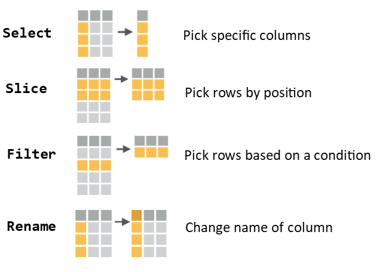

## Processing Data: Dados Originais

```r
flights
```

|  | carrier | origin | air_time | distance | dep_delay |
| --- | --- | --- | --- | --- | --- |
| 1 | UA | EWR | 227 | 1400 | 2 |
| 2 | UA | LGA | 227 | 1416 | 4 |
| 3 | AA | JFK | 160 | 1089 | 2 |
| 4 | B6 | JFK | 183 | 1576 | -1 |
| 5 | DL | LGA | 116 | 762 | -6 |

## Processando dados: Dados Originais

```r
flights %>%
  select(air_time)
```

|  | carrier | origin | air_time | distance | dep_delay |
| --- | --- | --- | --- | --- | --- |
| 1 | UA | EWR | 227 | 1400 | 2 |
| 2 | UA | LGA | 227 | 1416 | 4 |
| 3 | AA | JFK | 160 | 1089 | 2 |
| 4 | B6 | JFK | 183 | 1576 | -1 |
| 5 | DL | LGA | 116 | 762 | -6 |

## Processando dados: Dados Originais

```r
flights %>%
  select(air_time)
```

|  | air_time |
| --- | --- |
| 1 | 227 |
| 2 | 227 |
| 3 | 160 |
| 4 | 183 |
| 5 | 116 |

## Processando dados: Slice

```r
flights %>%
  slice(1:2)
```

|  | carrier | origin | air_time | distance | dep_delay |
| --- | --- | --- | --- | --- | --- |
| 1 | UA | EWR | 227 | 1400 | 2 |
| 2 | UA | LGA | 227 | 1416 | 4 |
| 3 | AA | JFK | 160 | 1089 | 2 |
| 4 | B6 | JFK | 183 | 1576 | -1 |
| 5 | DL | LGA | 116 | 762 | -6 |

## Processando dados: Slice

```r
flights %>%
  slice(1:2)
```

|  | carrier | origin | air_time | distance | dep_delay |
| --- | --- | --- | --- | --- | --- |
| 1 | UA | EWR | 227 | 1400 | 2 |
| 2 | UA | LGA | 227 | 1416 | 4 |

## Processando dados: Filter

```r
flights %>%
  filter(origin=="JFK")
```

|  | carrier | origin | air_time | distance | dep_delay |
| --- | --- | --- | --- | --- | --- |
| 1 | UA | EWR | 227 | 1400 | 2 |
| 2 | UA | LGA | 227 | 1416 | 4 |
| 3 | AA | JFK | 160 | 1089 | 2 |
| 4 | B6 | JFK | 183 | 1576 | -1 |
| 5 | DL | LGA | 116 | 762 | -6 |

## Processando dados: Filter

```r
flights %>%
  filter(origin=="JFK")
```

|  | carrier | origin | air_time | distance | dep_delay |
| --- | --- | --- | --- | --- | --- |
| 1 | AA | JFK | 160 | 1089 | 2 |
| 2 | B6 | JFK | 183 | 1576 | -1 |

## Processando dados: Rename

```r
flights %>%
  rename("airline"="carrier")
```

|  | carrier | origin | air_time | distance | dep_delay |
| --- | --- | --- | --- | --- | --- |
| 1 | UA | EWR | 227 | 1400 | 2 |
| 2 | UA | LGA | 227 | 1416 | 4 |
| 3 | AA | JFK | 160 | 1089 | 2 |
| 4 | B6 | JFK | 183 | 1576 | -1 |
| 5 | DL | LGA | 116 | 762 | -6 |

## Processando dados: Rename

```r
flights %>%
  rename("airline"="carrier")
```

|  | airline | origin | air_time | distance | dep_delay |
| --- | --- | --- | --- | --- | --- |
| 1 | UA | EWR | 227 | 1400 | 2 |
| 2 | UA | LGA | 227 | 1416 | 4 |
| 3 | AA | JFK | 160 | 1089 | 2 |
| 4 | B6 | JFK | 183 | 1576 | -1 |
| 5 | DL | LGA | 116 | 762 | -6 |

## Processando dados - Uma Lista de Ações

Segundo, ações para calcular a medida / estatística que precisamos

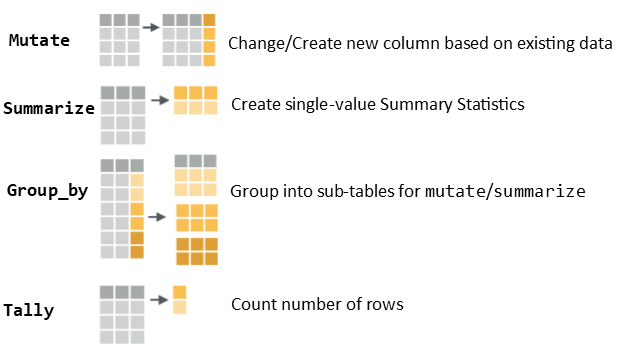

## Processing Data: Dados Originais

```r
flights
```

|  | carrier | origin | air_time | distance | dep_delay |
| --- | --- | --- | --- | --- | --- |
| 1 | UA | EWR | 227 | 1400 | 2 |
| 2 | UA | LGA | 227 | 1416 | 4 |
| 3 | AA | JFK | 160 | 1089 | 2 |
| 4 | B6 | JFK | 183 | 1576 | -1 |
| 5 | DL | LGA | 116 | 762 | -6 |

## Processando dados: Mutate

```r
flights %>%
  mutate(air_time=round(air_time/60,3))
```

|  | carrier | origin | air_time | distance | dep_delay |
| --- | --- | --- | --- | --- | --- |
| 1 | UA | EWR | 227 | 1400 | 2 |
| 2 | UA | LGA | 227 | 1416 | 4 |
| 3 | AA | JFK | 160 | 1089 | 2 |
| 4 | B6 | JFK | 183 | 1576 | -1 |
| 5 | DL | LGA | 116 | 762 | -6 |

## Processando dados: Mutate

```r
flights %>%
  mutate(air_time=round(air_time/60,3))
```

|  | carrier | origin | air_time | distance | dep_delay |
| --- | --- | --- | --- | --- | --- |
| 1 | UA | EWR | 3.783 | 1400 | 2 |
| 2 | UA | LGA | 3.783 | 1416 | 4 |
| 3 | AA | JFK | 2.667 | 1089 | 2 |
| 4 | B6 | JFK | 3.05 | 1576 | -1 |
| 5 | DL | LGA | 1.933 | 762 | -6 |

## Processando dados: Summarize

```r
flights %>%
  summarize(avg_distance=mean(distance,na.rm=TRUE))
```

|  | carrier | origin | air_time | distance | dep_delay |
| --- | --- | --- | --- | --- | --- |
| 1 | UA | EWR | 227 | 1400 | 2 |
| 2 | UA | LGA | 227 | 1416 | 4 |
| 3 | AA | JFK | 160 | 1089 | 2 |
| 4 | B6 | JFK | 183 | 1576 | -1 |
| 5 | DL | LGA | 116 | 762 | -6 |

## Processando dados: Summarize

```r
flights %>%
  summarize(avg_distance=mean(distance,na.rm=TRUE))
```

|  | avg_distance |
| --- | --- |
| 1 | 1248.6 |

## Processando dados: Tally

```r
flights %>%
  tally()
```

|  | n |
| --- | --- |
| 1 | 336776 |

## Processando dados: Group_by

```r
flights %>%
  group_by(carrier) %>%
  summarize(avg_distance=mean(distance,na.rm=TRUE))
```

|  | carrier | origin | air_time | distance | dep_delay |
| --- | --- | --- | --- | --- | --- |
| 1 | UA | EWR | 227 | 1400 | 2 |
| 2 | UA | LGA | 227 | 1416 | 4 |
| 3 | AA | JFK | 160 | 1089 | 2 |
| 4 | B6 | JFK | 183 | 1576 | -1 |
| 5 | DL | LGA | 116 | 762 | -6 |

## Processando dados: Group_by

```r
flights %>%
  group_by(carrier) %>%
  summarize(avg_distance=mean(distance,na.rm=TRUE))
```

|  | carrier | avg_distance |
| --- | --- | --- |
| 1 | AA | 1089 |
| 2 | B6 | 1576 |
| 3 | DL | 762 |
| 4 | UA | 1408 |

## Estratégias com Dados

Cada analise precisa uma sequência diferente de ações, mas uma estratégia geral é:

1. **Defina sua pergunta de pesquisa**
   - Desenhe seu data frame desejado primeiro!
2. **Refine o escopo da análise**
   - `filter` para as linhas relevantes
   - `select` e `rename` para tirar dados desnecessários
3. **‘Split’ os dados em subgrupos para análise** (se necessário)
   - `group_by` subgrupos
4. **‘Apply’ um cálculo ou resumo estatístico para cada subgrupo**
   - `summarize` ou `mutate`
5. **‘Combine’ para a sua unidade de análise desejada**

## Estratégias com Dados

1. **Defina sua pergunta de pesquisa**
   - Qual é o atraso médio para cada mês para cada companhia aérea que sai do JFK?
2. **Refine o escopo da análise**
   - `filter` só para JFK
   - `select` as variáveis de companhia aérea, mês e atraso
3. **‘Split’ os dados em subgrupos para análise**
   - `group_by` companhia aérea e mês
4. **‘Apply’ um cálculo ou resumo estatístico para cada subgrupo**
   - `summarize` para calcular o atraso médio
5. **‘Combine’ para a sua unidade de análise desejada**

## Estratégias com Dados

2 - Refine o escopo da análise  
- `filter` só para JFK

```r
flights_analysis <- flights %>% filter(origin=="JFK")
```

|  | carrier | origin | air_time | distance | dep_delay | month |
| --- | --- | --- | --- | --- | --- | --- |
| 1 | AA | JFK | 160 | 1089 | 2 | 1 |
| 2 | B6 | JFK | 183 | 1576 | -1 | 1 |
| 3 | B6 | JFK | 140 | 944 | -3 | 1 |
| 4 | B6 | JFK | 149 | 1028 | -2 | 1 |
| 5 | B6 | JFK | 158 | 1005 | -2 | 1 |

## Estratégias com Dados

2 - Refine o escopo da análise  
- `select` as variáveis de companhia aérea, mês e atraso

```r
flights_analysis <- flights_analysis %>%
  select(carrier,month,dep_delay)
```

|  | carrier | month | dep_delay |
| --- | --- | --- | --- |
| 1 | AA | 1 | 2 |
| 2 | B6 | 1 | -1 |
| 3 | B6 | 1 | -3 |
| 4 | B6 | 1 | -2 |
| 5 | B6 | 1 | -2 |

## Estratégias com Dados

3 - ‘Split’ os dados em subgrupos para análise  
- `group_by` companhia aérea e mês

```r
flights_analysis <- flights_analysis %>%
  group_by(carrier,month)
```

[output not shown]

## Estratégias com Dados

4 - ‘Apply’ um cálculo ou resumo estatístico para cada subgrupo  
- `summarize` para calcular o atraso médio

```r
flights_analysis <- flights_analysis %>%
  summarize(avg_delay=mean(dep_delay,na.rm=TRUE))
```

|  | carrier | month | avg_delay |
| --- | --- | --- | --- |
| 1 | 9E | 1 | 16.88 |
| 2 | 9E | 2 | 16.49 |
| 3 | 9E | 3 | 13.41 |
| 4 | 9E | 4 | 13.57 |
| 5 | 9E | 5 | 22.67 |
| 6 | AA | 1 | 6.93 |
| 7 | AA | 2 | 8.28 |
| 8 | AA | 3 | 8.7 |
| 9 | AA | 4 | 11.7 |
| 10 | AA | 5 | 9.66 |

[output cut: 70 more lines]

## Estratégias com Dados

5 - ‘Combine’ para a sua unidade de análise desejada

## Estratégias com Dados

Tudo juntos:

```r
flights_analysis <- flights %>% filter(origin=="JFK") %>%
  select(carrier,month,dep_delay) %>%
  group_by(carrier,month) %>%
  summarize(avg_delay=mean(dep_delay,na.rm=TRUE))
```